# STA465 Final Project Report

Imtiaz Kidwai

2025-12-21

# Spatial Analysis of the 2025 Canadian Federal Election

## Introduction

Canada is a large country with a lot of diversity. Voting patterns in Canada are not uniform across groups of people. Some groups are more likely to vote for a particular political party than other groups. Furthermore, different parts of the country exhibit different voting patterns. For example, Alberta is infamous for for its loyalty to the Conservative Party of Canada, but the CPC’s performace in Quebec is usually lacklustre compared to other parties. Investigating these patterns is crucial for parties to allocate their campaigning resources come election time. They are also crucial for us to investigate as a whole, as it helps us understand how the parties that govern us can improve their policies to better suit particular groups.

I have datasets that include a shape file for electoral districts under the 2023 federal electoral boundaries, voting results for the 2025 federal elections, and 2021 census data for these electoral districts. The research goal of this project is to analyze the effect of certain features on vote share of the three major parties in the 2025 federal election: Liberal Party of Canada (LPC), Conservative Party of Canada (CPC) and the New Democratic Party (NDP). I want to analyze the demographics the parties enjoyed support from in the most recent election and compare the electoral performance with certain groups across the three major parties. Figure 1 maps the result of the 2025 Canadian federal election.

[interactive chart not shown]

Figure 1: Result of the 2025 Canadian Federal Election

Figure 2 displays a map of the vote share for each of the three major parties.

[interactive chart not shown]

Figure 2: Map of vote share for each of the three major parties

Table 1 provides a summary of the variables that will be used in this analysis.

Table 1: Summary of all the variables of interest

| Variable | Mean | Standard Deviation | Minimum | Maximum | Median |
| --- | --- | --- | --- | --- | --- |
| LPC Vote Share | 43.919534 | 13.5762627 | 0.000 | 68.300 | 45.200 |
| CPC Vote Share | 40.984840 | 16.7607678 | 0.000 | 83.700 | 42.300 |
| NDP Vote Share | 6.499708 | 7.7666723 | 0.000 | 46.800 | 3.900 |
| Proportion of population aged between 20 and 29 | 12.416726 | 3.2549940 | 6.826 | 30.687 | 11.711 |
| Proportion of population aged between 30 and 49 | 26.180566 | 3.6198367 | 19.610 | 45.733 | 25.757 |
| Proportion of population aged between 50 and 65 | 20.559052 | 2.5062864 | 10.071 | 27.309 | 20.738 |
| Proportion of population aged 65 and above | 19.055102 | 4.7948585 | 4.400 | 31.900 | 18.800 |
| First Generation Proportion | 25.067347 | 18.6934453 | 1.600 | 71.000 | 20.200 |
| Second Generation Proportion | 16.781633 | 8.6131876 | 1.100 | 38.000 | 18.100 |
| Third Generation and above Proportion | 58.151604 | 26.2754024 | 3.400 | 97.200 | 63.200 |
| Average Household Size | 2.474052 | 0.3703920 | 1.600 | 4.300 | 2.400 |
| Total Men Proportion | 49.296408 | 0.9450859 | 46.331 | 53.777 | 49.285 |
| Total Women Proportion | 50.703662 | 0.9449454 | 46.232 | 53.669 | 50.711 |
| Post Secondary Education Proportion | 56.564140 | 8.3979267 | 26.600 | 85.400 | 55.700 |
| Visible Minority Proportion | 25.023324 | 23.1368275 | 0.800 | 93.200 | 16.800 |

## Methods

### Analysis of Spatial Autocorrelation

I want to determine what the spatial pattern looks like for the vote share of the three major parties. I expect significant spatial clustering, and analyzing the Moran’s I statistic will help us verify my hypothesis.

Queen: Two districts are neighbours if they share a common singular point.

Rook: Two districts are neighbours if they share a common border.

3-nearest neighbours: A district’s neighbours are the 3 districts with the closest centroids.

5-nearest neighbours: A district’s neighbours are the 5 districts with the closest centroids.

[interactive chart not shown]

Figure 3: Map of neighbours based on the different adjacency matrices.

I started with global Moran’s I. It defines spatial similarities via deviations from the mean. A global Moran’s I test has a test statistic $\frac{I - \mathbb{E}[I]}{\sqrt{Var(I)}}$, and the null hypothesis is that there is no spatial correlation. Table 2a, 2b and 2c report the test results for each party.

Table 2a: Global Moran’s I test results for LPC vote share

| Neighbourhood Type | Moran’s I statistic | p-value |
| --- | --- | --- |
| Queen | 0.602 | 0 |
| Rook | 0.603 | 0 |
| KN3 | 0.536 | 0 |
| KN5 | 0.494 | 0 |

Table 2b: Global Moran’s I test results for NDP vote share

| Neighbourhood Type | Moran’s I statistic | p-value |
| --- | --- | --- |
| Queen | 0.331 | 0 |
| Rook | 0.332 | 0 |
| KN3 | 0.366 | 0 |
| KN5 | 0.276 | 0 |

Table 2c: Global Moran’s I test results for CPC vote share

| Neighbourhood Type | Moran’s I statistic | p-value |
| --- | --- | --- |
| Queen | 0.756 | 0 |
| Rook | 0.755 | 0 |
| KN3 | 0.678 | 0 |
| KN5 | 0.631 | 0 |

We see that Moran’s I statistic is positive for every adjacency matrix for every party’s vote share, so we can conclude that party vote shares are displaying clustering. The p-values are all less than 0.05 so I reject the null hypothesis that the spatial correlation is random.

To further compare and contrast, we can look at the lag structure of the statistic by analyzing correlograms in figures 4, 5 and 6.

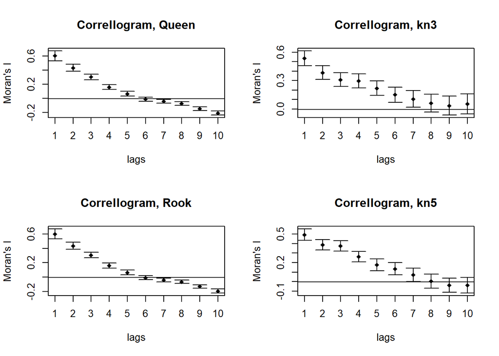

Figure 4: Correlograms for each adjacency matrix for the LPC’s vote share

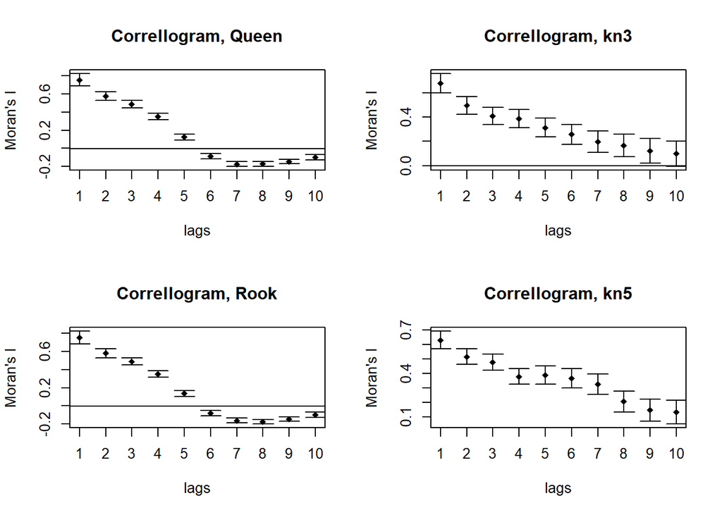

Figure 5: Correlograms for each adjacency matrix for the CPC’s vote share

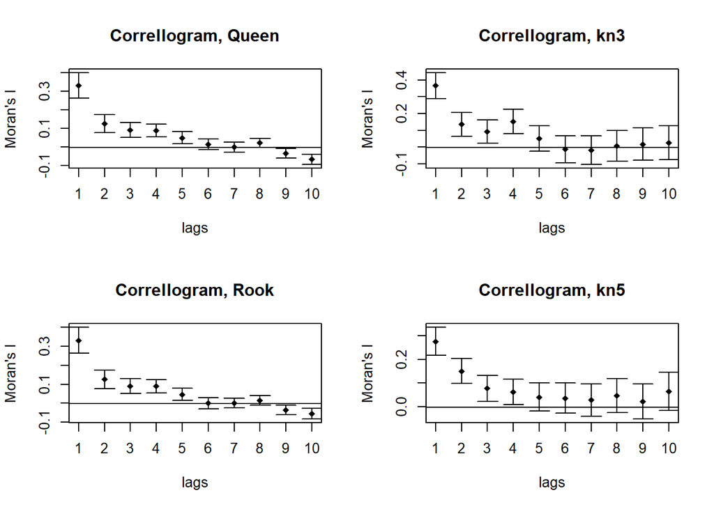

Figure 6: Correlograms for each adjacency matrix for the NDP’s vote share

We can also do a Geary c test, which is another test for global association. It helps us identify strong local contrasts. Tables 3a, 3b and 3c report the test results for each party’s vote share.

Table 3a: Geary’s c test results for LPC vote share

| Neighbourhood Type | Geary’s c statistic | p-value |
| --- | --- | --- |
| Queen | 0.401 | 0 |
| Rook | 0.401 | 0 |
| KN3 | 0.437 | 0 |
| KN5 | 0.478 | 0 |

Table 3b: Geary’s c test results for CPC vote share

| Neighbourhood Type | Geary’s c statistic | p-value |
| --- | --- | --- |
| Queen | 0.265 | 0 |
| Rook | 0.267 | 0 |
| KN3 | 0.276 | 0 |
| KN5 | 0.333 | 0 |

Table 3c: Geary’s c test results for NDP vote share

| Neighbourhood Type | Geary’s c statistic | p-value |
| --- | --- | --- |
| Queen | 0.657 | 0 |
| Rook | 0.653 | 0 |
| KN3 | 0.743 | 0 |
| KN5 | 0.779 | 0 |

Now, I will take a look at local clustering by analyzing local Moran’s I. At this point, we’re going to pick the queen adjacency matrix since the Moran’s I and Geary’s c test results are in line with what we expected, and it makes sense to treat any federal districts that share a point with each other as neighbours for my research question. While the nearest neighbours approach was appealing, it did not make sense to me to fix the amount of neighbours for each district.

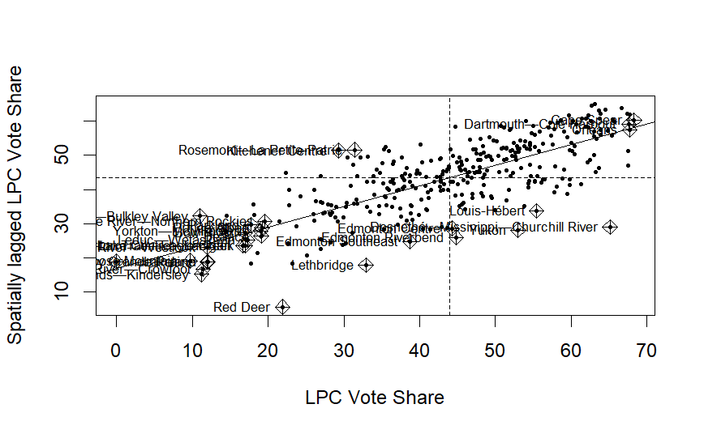

Figure 7a: Moran Scatterplot for LPC vote share

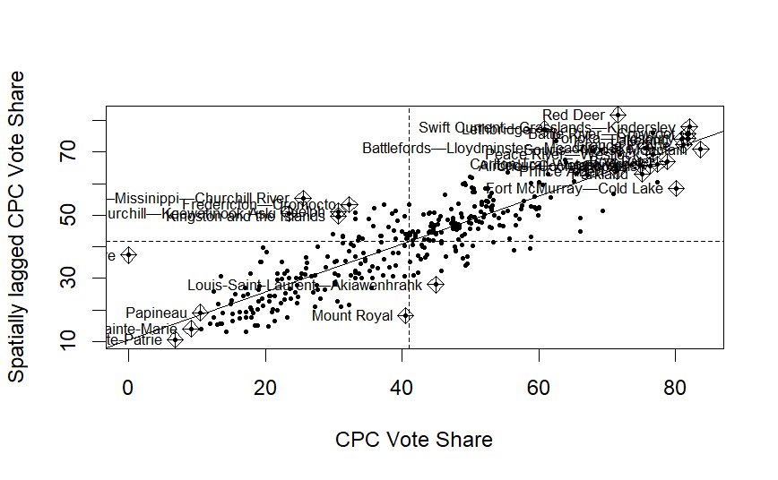

Figure 7b: Moran Scatterplot for CPC vote share

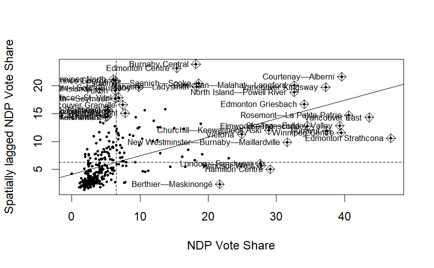

Figure 7c: Moran Scatterplot for NDP vote share

Now, we can use local Moran’s I to classify neighbourhoods by type of clustering attribute.

[interactive chart not shown]

Figure 8: Local Moran’s I for all three parties

Lastly, for the NDP’s vote share, almost all of Southern Ontario, Quebec and Atlantic Canada barring the major cities are low-value clusters for the NDP’s vote share. Outside of this region, rural Canadian districts are generally under the High-High quadrants with the exception of some Western Albertan districts. Downtown cores of the major metropolitan cities generally fall under the High-High quadrant too, and the districts around the downtown core are High-Low.

### Spatial Modelling

I shall now start building spatial regression models for vote share for all three parties. I identified variables of interest in the Introduction section. Using the OLS linear model, I shall analyze the linear relationship between vote share and the covariates. Tables 4a, 4b and 4c show results of the OLS model for the LPC, CPC and NDP vote share respectively.

Table 4a: Coefficients of OLS Model for LPC Vote Share

|  | Estimate | Std. Error | t value | Pr(>\|t\|) |
| --- | --- | --- | --- | --- |
| (Intercept) | 270.0047255 | 40.0765937 | 6.7372174 | 0.0000000 |
| `Proportion of population aged between 20 and 29` | 2.4746611 | 0.2956028 | 8.3715757 | 0.0000000 |
| `Proportion of population aged between 50 and 65` | 2.4552647 | 0.3731490 | 6.5798499 | 0.0000000 |
| `Proportion of population aged 65 and above` | -0.2977009 | 0.2181412 | -1.3647166 | 0.1732636 |
| `First Generation Proportion` | -0.1355131 | 0.1664004 | -0.8143801 | 0.4160092 |
| `Second Generation Proportion` | -0.1387955 | 0.1302975 | -1.0652203 | 0.2875480 |
| `Average Household Size` | 5.1096989 | 2.7206871 | 1.8780913 | 0.0612423 |
| `Total Men Proportion` | -6.7521686 | 0.7164806 | -9.4240775 | 0.0000000 |
| `Post Secondary Education Proportion` | 0.3878711 | 0.0869183 | 4.4624785 | 0.0000111 |
| `Visible Minority Proportion` | 0.0953109 | 0.1173769 | 0.8120072 | 0.4173676 |

Table 4b: Coefficients of OLS Model for CPC Vote Share

|  | Estimate | Std. Error | t value | Pr(>\|t\|) |
| --- | --- | --- | --- | --- |
| (Intercept) | -101.0372092 | 55.5289065 | -1.8195426 | 0.0697265 |
| `Proportion of population aged between 20 and 29` | -1.5636686 | 0.4095782 | -3.8177533 | 0.0001606 |
| `Proportion of population aged between 50 and 65` | -1.2618896 | 0.5170239 | -2.4406791 | 0.0151803 |
| `Proportion of population aged 65 and above` | 0.1922592 | 0.3022498 | 0.6360937 | 0.5251523 |
| `First Generation Proportion` | 0.4444959 | 0.2305593 | 1.9279031 | 0.0547173 |
| `Second Generation Proportion` | 0.6604077 | 0.1805363 | 3.6580338 | 0.0002953 |
| `Average Household Size` | 10.0708412 | 3.7697011 | 2.6715225 | 0.0079219 |
| `Total Men Proportion` | 3.7141601 | 0.9927337 | 3.7413460 | 0.0002155 |
| `Post Secondary Education Proportion` | -0.6094449 | 0.1204314 | -5.0605159 | 0.0000007 |
| `Visible Minority Proportion` | -0.4813686 | 0.1626338 | -2.9598312 | 0.0032987 |

Table 4c: Coefficients of OLS Model for NDP Vote Share

|  | Estimate | Std. Error | t value | Pr(>\|t\|) |
| --- | --- | --- | --- | --- |
| (Intercept) | 21.1380908 | 28.1014215 | 0.7522072 | 0.4524578 |
| `Proportion of population aged between 20 and 29` | 0.3588664 | 0.2072746 | 1.7313577 | 0.0843142 |
| `Proportion of population aged between 50 and 65` | -0.2653131 | 0.2616495 | -1.0140021 | 0.3113179 |
| `Proportion of population aged 65 and above` | -0.3108833 | 0.1529591 | -2.0324609 | 0.0429002 |
| `First Generation Proportion` | -0.0414898 | 0.1166787 | -0.3555903 | 0.7223726 |
| `Second Generation Proportion` | 0.2805412 | 0.0913637 | 3.0705982 | 0.0023121 |
| `Average Household Size` | -11.1692453 | 1.9077264 | -5.8547417 | 0.0000000 |
| `Total Men Proportion` | 0.6927762 | 0.5023911 | 1.3789580 | 0.1688332 |
| `Post Secondary Education Proportion` | -0.3259814 | 0.0609465 | -5.3486482 | 0.0000002 |
| `Visible Minority Proportion` | 0.0214620 | 0.0823038 | 0.2607650 | 0.7944349 |

The spatial models in this analysis are the SAR Lag, SAR Error, SAR Lag-Error and CAR models.

The SAR lag model takes the form of $Y =\rho WY + X\beta + \epsilon$. True to its name, what separates it from my classic OLS model is the addition of the lag term $\rho WY$, where $\rho$ is a spatial weight and $W$ is the row-standardized queen weight matrix I have. In addition, I still have my covariates $X$ and I fit the coefficient parameters in the $\beta$ vector. $\epsilon \sim N(0, \sigma^2 I)$ is the error term as usual. Importantly, I do not have a lag for the covariates. By spatially lagging $Y$ with the weight matrix $W$, each unit is influenced by a neighbouring unit. To fit the mode, the ML log-likelihood has to be maximized with respect to $\rho$, $\beta$ and $\sigma^2$. The ML log-likelihood is $l(\rho, \beta, \sigma^2) = -\frac{n}{2}\log(2\pi\sigma^2) + \log|I - \rho W| - \frac{1}{2\sigma^2} r'r$.

The SAR Error model takes the form $Y = X \beta + u$ where $u = \lambda W u + \epsilon$. Instead of spatially lagging $Y$, I spatially lag the error term. This allows us to focus on the relationship between $Y$ and the covariates since $E[Y] = X\beta$, and it’s the error terms that have to account for spatial patterns. $\lambda$ is a special weight, $W$ is the weight matrix, $\epsilon \sim N(0, \sigma^2 I)$ is the final error term in addition to my linear model $X \beta$ where $X$ is covariate matrix and $\beta$ is the vector of the coefficient parameters, as usual. The log likelihood is $l(\lambda, \beta, \sigma^2) = - \frac{n}{2} \log(2 \pi \sigma^2) + \log|1 - \lambda W| - \frac{1}{2 \sigma^2} e' e$, and I can estimate the parameters $\lambda, \beta, \sigma^2$ by maximizing the log-likelihood with respect to these parameters.

The SAR Spatial Lag-Error model combines the previous two models. I now have both a spatial lag in the mean and spatial autoregression in the errors. Each unit is influenced by neighbouring units and each unit shares similar error patterns with neighbouring units. The model is $Y = \rho W Y + X\beta + u$ where $u = \lambda W u + \epsilon$. $\rho$ captures the spatial pattern and $\lambda$ captures the pattern of the errors controlling for $X$ and $\rho W Y$. Recall that $X$ is the covariate matrix, $\beta$ is coefficient parameter vector, $W$ is the weight matrix and $\epsilon \sim N(0, \sigma^2 I)$ is the final error term. To estimate $\rho, \lambda, \beta, \sigma^2$, I must maximize with respect to these parameters the log-likelihood $l(\rho, \lambda, \beta, \sigma^2) = -\frac{n}{2} \log (2 \pi \sigma^2 ) + \log|I - \rho W| + \log|I - \lambda W| - \frac{1}{2\sigma^2} e'e$.

CAR models use conditional distributions instead of the joint distributions I see in SAR models. I assume $Y_i | Y_{-i} \sim N(\mu_i + \sum_{j \in N_i}c_{ij} (Y_j - \mu_j), \sigma_i^2)$, $\mu_i = x_i^T \beta$. I have that $c_{ii} = 0$ and $c_{ij} \neq 0$ . I also require $\sigma_i^2 c_{ij} = \sigma_j^2 c_{ji}$. Under this, I have the joint distribution $Y \sim N(X\beta, Q^{-1})$, $Q$ is sparse. I have two ways to estimate the parameters. The Bayesian way is to have prior distributions for $\beta, \tau,\rho$ and sample or find a posterior. The frequentist way is to maximize the likelihood $l(\beta, \tau, \rho) = - \frac{1}{2} \log |Q|- \frac{1}{2} (Y - X \beta)^T Q(Y - X \beta) + C$ for some constant $C$.

Tables 5a, 5b and 5c report the coefficients for each spatial model for the vote share of the LPC, CPC and NDP respectively.

Table 5a: Spatial Models for LPC Vote Share

|  | OLS | SAR Lag | SAR Error | SAR Lag Error | CAR |
| --- | --- | --- | --- | --- | --- |
| (Intercept) | 270.005 | 171.459 | 151.763 | 152.096 | 126.983 |
| `Proportion of population aged between 20 and 29` | 2.475 | 1.510 | 1.205 | 1.107 | 1.955 |
| `Proportion of population aged between 50 and 65` | 2.455 | 0.840 | 0.873 | 0.884 | 2.416 |
| `Proportion of population aged 65 and above` | -0.298 | 0.013 | -0.004 | -0.058 | -0.192 |
| `First Generation Proportion` | -0.136 | -0.221 | 0.012 | 0.097 | 0.075 |
| `Second Generation Proportion` | -0.139 | -0.080 | 0.027 | 0.126 | -0.117 |
| `Average Household Size` | 5.110 | 5.838 | 6.402 | 5.674 | 10.557 |
| `Total Men Proportion` | -6.752 | -4.394 | -3.739 | -3.464 | -4.171 |
| `Post Secondary Education Proportion` | 0.388 | 0.309 | 0.439 | 0.414 | 0.508 |
| `Visible Minority Proportion` | 0.095 | 0.114 | 0.088 | 0.058 | -0.089 |

Table 5b: Spatial Models for CPC Vote Share

|  | OLS | SAR Lag | SAR Error | SAR Lag Error | CAR |
| --- | --- | --- | --- | --- | --- |
| (Intercept) | -101.037 | -83.584 | -30.854 | -83.352 | 646.756 |
| `Proportion of population aged between 20 and 29` | -1.564 | -1.215 | -1.142 | -1.221 | -0.398 |
| `Proportion of population aged between 50 and 65` | -1.262 | -0.113 | -0.068 | -0.122 | -1.938 |
| `Proportion of population aged 65 and above` | 0.192 | 0.030 | 0.096 | 0.041 | -0.472 |
| `First Generation Proportion` | 0.444 | 0.461 | 0.508 | 0.474 | -0.007 |
| `Second Generation Proportion` | 0.660 | 0.088 | 0.166 | 0.110 | 0.487 |
| `Average Household Size` | 10.071 | 2.877 | 3.099 | 3.130 | -40.323 |
| `Total Men Proportion` | 3.714 | 2.126 | 1.675 | 2.148 | -11.527 |
| `Post Secondary Education Proportion` | -0.609 | -0.164 | -0.210 | -0.178 | -0.673 |
| `Visible Minority Proportion` | -0.481 | -0.310 | -0.385 | -0.328 | 0.737 |

Table 5c: Spatial Models for NDP Vote Share

|  | OLS | SAR Lag | SAR Error | SAR Lag Error | CAR |
| --- | --- | --- | --- | --- | --- |
| (Intercept) | 21.138 | 11.347 | 18.153 | 14.226 | -20.410 |
| `Proportion of population aged between 20 and 29` | 0.359 | 0.367 | 0.326 | 0.349 | 0.301 |
| `Proportion of population aged between 50 and 65` | -0.265 | 0.016 | 0.009 | 0.012 | 0.019 |
| `Proportion of population aged 65 and above` | -0.311 | -0.301 | -0.446 | -0.355 | -0.359 |
| `First Generation Proportion` | -0.041 | -0.062 | -0.109 | -0.070 | 0.006 |
| `Second Generation Proportion` | 0.281 | 0.204 | 0.292 | 0.230 | 0.296 |
| `Average Household Size` | -11.169 | -8.651 | -9.574 | -9.248 | -7.484 |
| `Total Men Proportion` | 0.693 | 0.533 | 0.611 | 0.562 | 1.238 |
| `Post Secondary Education Proportion` | -0.326 | -0.258 | -0.298 | -0.277 | -0.278 |
| `Visible Minority Proportion` | 0.021 | 0.036 | 0.039 | 0.035 | -0.071 |

In addition, Table 6a, 6b, 6c and 6d report the parameters pertinent to each type of model for each party.

Table 6a: Parameter Estimates for SAR Lag model

| Party | rho | LRT statistic | LRT p-value |
| --- | --- | --- | --- |
| LPC | 0.5742403 | 118.44798 | 0 |
| CPC | 0.8036782 | 330.32436 | 0 |
| NDP | 0.4717776 | 49.40531 | 0 |

Table 6b: Parameter Estimates for SAR error model

| Party | lambda | LRT statistic | LRT p-value |
| --- | --- | --- | --- |
| LPC | 0.7222848 | 125.3288 | 0 |
| CPC | 0.8544180 | 313.8428 | 0 |
| NDP | 0.5169507 | 47.5009 | 0 |

Table 6c: Parameter Estimates for SAR Lag Error model

| Party | rho | lambda | LRT statistic | LRT p-value |
| --- | --- | --- | --- | --- |
| LPC | -0.2727290 | 0.8299532 | 128.95190 | 0 |
| CPC | 0.7706361 | 0.1217538 | 331.21212 | 0 |
| NDP | 0.3631217 | 0.1664991 | 49.97567 | 0 |

Table 6d: Parameter Estimates for CAR model

| Party | lambda | LRT statistic | LRT p-value |
| --- | --- | --- | --- |
| LPC | 0.3424182 | 23.43544 | 1.3e-06 |
| CPC | 0.9946739 | 4954.65324 | 0.0e+00 |
| NDP | 0.7396949 | 39.95238 | 0.0e+00 |

Table 7: Moran’s I for residuals of all models

| Model Residuals | Moran’s I statistic | p-value |
| --- | --- | --- |
| OLS [LPC] | 0.364 | 0.000 |
| SAR Lag [LPC] | 0.007 | 0.392 |
| SAR Error [LPC] | -0.031 | 0.790 |
| SAR Lag Error [LPC] | 0.007 | 0.392 |
| CAR [LPC] | 0.219 | 0.000 |
| OLS [CPC] | 0.611 | 0.000 |
| SAR Lag [CPC] | 0.022 | 0.238 |
| SAR Error [CPC] | -0.003 | 0.503 |
| SAR Lag Error [CPC] | 0.022 | 0.238 |
| CAR [CPC] | -0.149 | 1.000 |
| OLS [NDP] | 0.239 | 0.000 |
| SAR Lag [NDP] | 0.010 | 0.348 |
| SAR Error [NDP] | 0.003 | 0.426 |
| SAR Lag Error [NDP] | 0.010 | 0.348 |
| CAR [NDP] | -0.097 | 0.997 |

The p-values are almost 0 for each of the OLS models, so the OLS residuals show spatial autocorrelation. In addition, the only the other model whose residuals show spatial autocorrelation is the CAR model for the LPC’s vote share. All the other models successfully deal with spatial autocorrelation.

We can now compare the different types of models and choose one to analyze.

Table 8a: Metrics for Model Comparison [LPC]

| Model | AIC | BIC |
| --- | --- | --- |
| SAR Lag | 2435.882 | 2481.935 |
| SAR Error | 2429.001 | 2475.054 |
| SAR Lag Error | 2427.378 | 2477.269 |
| CAR | 2530.895 | 2576.947 |

Table 8b: Metrics for Model Comparison [CPC]

| Model | AIC | BIC |
| --- | --- | --- |
| SAR Lag | 2447.718 | 2493.771 |
| SAR Error | 2464.200 | 2510.252 |
| SAR Lag Error | 2448.830 | 2498.721 |
| CAR | -2176.611 | -2130.558 |

Table 8c: Metrics for Model Comparison [NDP]

| Model | AIC | BIC |
| --- | --- | --- |
| SAR Lag | 2261.414 | 2307.466 |
| SAR Error | 2263.318 | 2309.371 |
| SAR Lag Error | 2262.843 | 2312.734 |
| CAR | 2270.867 | 2316.919 |

The CAR model for the CPC vote share has abnormally low AIC and BIC. Intuitvely, CAR models make sense for election modelling, but because the residuals of the CAR model for LPC vote share showed spatial autocorrelation, and I want to keep the model fit consistent for all three parties, I cannot proceed with the CAR model. Since the AIC and BIC is similar for all the other models across all three parties, we’re going to choose the SAR Error model because we can interpret the direct effects easily and not have to worry about interpreting the indirect spatial effects from the SAR Lag model.

## Result

Table 9 shows the direct regression effects as fitted by the SAR Error model.

Table 9: Results of the SAR Error Model for all three parties

|  | LPC | CPC | NDP |
| --- | --- | --- | --- |
| (Intercept) | 151.7628902 | -30.8544188 | 18.1533471 |
| `Proportion of population aged between 20 and 29` | 1.2051716 | -1.1415379 | 0.3261513 |
| `Proportion of population aged between 50 and 65` | 0.8728996 | -0.0679895 | 0.0087189 |
| `Proportion of population aged 65 and above` | -0.0035712 | 0.0959134 | -0.4456705 |
| `First Generation Proportion` | 0.0116944 | 0.5081090 | -0.1093097 |
| `Second Generation Proportion` | 0.0271098 | 0.1656239 | 0.2918990 |
| `Average Household Size` | 6.4017952 | 3.0991094 | -9.5736463 |
| `Total Men Proportion` | -3.7394373 | 1.6754975 | 0.6109544 |
| `Post Secondary Education Proportion` | 0.4390393 | -0.2095993 | -0.2981052 |
| `Visible Minority Proportion` | 0.0882676 | -0.3845627 | 0.0394240 |

The reference group for immigrant generations is third generation or above, so a hypothetical one percent increase in other groups means a one percent decrease in the percent of the population that is third generation or above. A one percentage point increase in the proportion of first generation immigrant results in a 0.01% increase in the LPC’s expected vote share, a 0.51% increase in the CPC’s expected vote share and and a 0.1% decrease in the NDP’s expected vote share. A one percent increase in the proportion of second generation immigrant results in a 0.02% increase in the LPC’s expected vote share, a 0.17% increase in the CPC’s expected vote share and a 0.29% increase in the NDP’s vote share.

A one percent increase in average household size results in a 6.4% increase in the LPC’s expected vote share, a 3.1% in the CPC’s expected vote share and a 9.6% decrease in the NDP’s expected vote share. Thus, the larger the average household size, the more the LPC and CPC gained at the expense of the NDP.

When analyzing education status , we see that a one percent increase in the proportion of the population that completed post-secondary education results in a 0.44% increase in the expected LPC vote share, 0.2% decrease in the expected CPC vote share and a 0.3% decrease in the expected NDP vote share. The LPC enjoys a boost in vote share in a riding with more post-secondary educated people at the expense of both the CPC and NDP.

Finally, a one percent increase in the percent of population that is a visible minority results in a 0.09% increase in the expected LPC vote share, 0.38% decrease in the expected CPC vote share and a 0.04% increase in the NDP vote share. The CPC’s vote share declines while the LPC and NDP’s vote share marginally increases when there is a higher proportion of visible minorities.

## Conclusion

Elections are very complex, and there are many other factors that affects a party’s performance in a federal district that I couldn’t take into account either because the data was not available in the census, or because I did not have the tools to handle them. An example for the latter case is ethnic groups. There are many ethnic groups in Canada, and it would have been impossible to incorporate all of them in the models.

In addition, I could not include the Bloc Quebecois and Green Party of Canada in this project because the parties did not run candidates in many of the electoral districts. Perhaps another flaw of this project was the separate analysis of each political party’s vote share. There are multivariate models out there that I was not familiar enough with to use, but those models may have been better suited for my research question. As mentioned before, CAR models may have been better suited for my goals because it would have helped captured local spatial autocorrelation.

Using Moran’s I and Geary’s c, I concluded that the vote share for all three parties were spatially autocorrelated.

In the 2025 election, the LPC did well with the youngest age group (20-29) and the 50-65 age group. The CPC performed poorly with the youngest age group and saw a relatively uniform performance among people aged 30 and over. For the NDP, their vote share generally declined as the age groups got older. The LPC performed similarly across immigrant generations in the 2025 election, while the CPC performed better the later the immigrants in the federal district arrived to Canada, and the NDP performed better with second generation immigrants in particular. The CPC received more support from men than the LPC while LPC performed better in ridings with a higher proportion of women, and the NDP’s vote was relatively uniform across men and women. The LPC and CPC’s expected vote share increased when the average household size in a riding increased, while the NDP’s expected vote share plummeted. The LPC performed better with people who recieved post-secondary education at the expense of both the CPC and NDP. The CPC performed worse with visible minorities while the LPC and NDP performed slightly better with visible minorities.

These were some of the many trends unearthed by the 2025 federal election. It is common for political parties to study these trends to reflect on their political strategy and adapt it for future elections. As such, it is helpful for voters to get a glimpse of these trends too and use them as part of facts-based political discourse.

## Data Sources

Canada, E. (n.d.). 45th General Election – April 28, 2025. Elections Canada. https://www.elections.ca/content.aspx?section=ele&dir=pas/45ge&document=index&lang=e

Electoral Geography Boundary Files (45th General Election) - Canada 2025 - Open Government Portal. (n.d.). https://open.canada.ca/data/en/dataset/97a2a33c-54cc-4f2e-82c1-047ad8212f05

Government of Canada, Statistics Canada. (2023, November 15). Census Profile Downloads, 2021. https://www12.statcan.gc.ca/census-recensement/2021/dp-pd/prof/details/download-telecharger.cfm?Lang=E